# Aktuelle Data Science-Entwicklungen - Intelligent Text Analysis

Project Presentation Moritz Schlager & Timo Heiß

**Holly**: So you missed something really big.  
**Michael**: It was bigger than I thought.  
**Holly**: Well that’s what you said-  
**Michael**: No I didn’t say it. Oh no no I didn’t say it. Why are you smiling so much?  
[...]

# That’s what the data said: An NLP Analysis of Script Lines from the US TV-Show "The Office"

## The Office

- comedy TV series that follows the daily lives of a group of office workers at the paper company "Dunder Mifflin"
- mockumentary style to show interactions, conflicts and humor
- more information will be provided by our analysis
- goal: analyze script lines of the show using various traditional and modern NLP-methods to tell more about the office by only looking at the written dialogues

# 1. Dataset and Data Understanding

## The Dataset

Dataset: https://data.world/abhinavr8/the-office-scripts-dataset. (27.01.2023)

```python
df.head(3)
```

| id | season | episode | scene | line_text | speaker | deleted |
| --- | --- | --- | --- | --- | --- | --- |
| 1 | 1 | 1 | 1 | All right Jim. Your quarterlies look very good... | Michael | False |
| 2 | 1 | 1 | 1 | Oh, I told you. I couldn't close it. So... | Jim | False |
| 3 | 1 | 1 | 1 | So you've come to the master for guidance? Is ... | Michael | False |

```python
df.iloc[24:25]
```

| id | season | episode | scene | line_text | speaker | deleted |
| --- | --- | --- | --- | --- | --- | --- |
| 25 | 1 | 1 | 7 | [Strains, grunts] What? | Michael | False |

```python
df.shape
```

```
(59911, 6)
```

### Value Analysis

```python
df.describe(include="all").fillna("-")
```

|  | season | episode | scene | line_text | speaker | deleted |
| --- | --- | --- | --- | --- | --- | --- |
| count | 59911.0 | 59911.0 | 59911.0 | 59911 | 59911 | 59911 |
| unique | - | - | - | 52187 | 794 | 2 |
| top | - | - | - | Yeah. | Michael | False |
| freq | - | - | - | 486 | 12137 | 57975 |
| mean | 5.348283 | 11.558295 | 27.143613 | - | - | - |
| std | 2.389458 | 6.986292 | 17.860703 | - | - | - |
| min | 1.0 | 1.0 | 1.0 | - | - | - |
| 25% | 3.0 | 5.0 | 14.0 | - | - | - |
| 50% | 5.0 | 11.0 | 25.0 | - | - | - |
| 75% | 7.0 | 18.0 | 37.0 | - | - | - |
| max | 9.0 | 26.0 | 116.0 | - | - | - |

- 9 seasons with a maximum of 26 episodes with at most 116 scenes
- 52187 of the 59911 spoken lines are unique
- "Yeah." is the most frequently spoken line with a total of 486 occurrences
- there are 794 different people speaking throughout the show
- Michael is the character with the most lines with total number of 12137 lines
- 57975 of the available 59911 lines actually made it into the final version of the show

### Issues

- very few missing lines in scenes (discovered by watching the show and checking the dataset)
- "show within a show" scenes (e.g. when characters are watching TV / are listing to the radio) are displayed in a unclear manor
- sometimes different names for the same speaker

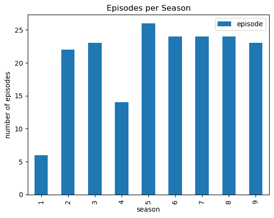

```python
df[["season", "episode"]].drop_duplicates().groupby("season").count().plot.bar()
plt.title("Episodes per Season")
plt.ylabel("number of episodes")
plt.show()
```

- some episodes seem to be missing: difference to https://en.wikipedia.org/wiki/List_of_The_Office_(American_TV_series)_episodes
- research result: double episodes (e.g. season 2, episode 1 and 2) are listed as one episode in the dataset

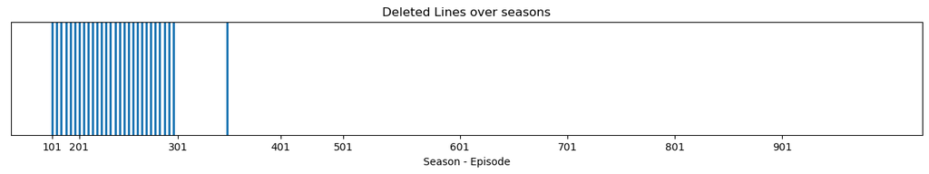

```python
# show the deleted lines over the seasons
df["season_episode"] = df.apply(lambda x: f"{x['season']}{'0' if x['episode']<10 else ''}{x['episode']}", axis=1)

plt.figure(figsize=(16,2))
plt.scatter(df["season_episode"], df["deleted"].sort_index(), alpha=0.5, s=10, c="white")
plt.vlines(df["season_episode"].loc[df["deleted"]==True], ymin=0, ymax=1, linewidths=1)
plt.xticks(["101", "201", "301", "401", "501", "601", "701", "801", "901"])
plt.yticks([])
plt.ylim(0,1)
plt.xlabel("Season - Episode")
plt.title("Deleted Lines over seasons")
plt.show()
```

- deleted scenes only occur in the first 2 seasons (with one exception in season 3)
- therefore, they are not considered in the following analysis